# WUM - Praca domowa 2

Patryk Wrona

30.03.2020

# 1 Kodowanie zmiennych kategorycznych

## 1.1 Target encoding

Zagadnienie target encoding polega na policzeniu średniej ceny dla każdej lokacji (it_location). Jeśli wprowadzilibyśmy losowe szumy(czyli dodalibyśmy albo odjelibyśmy bardzo małe wartości do wynikowych cen), pomogłoby to nam uniknąć sytuacji, w której taka sama cena przyporządkowana jest więcej niż 1 lokacji. Wynik przedstawiam poniżej:

```r
##    LADOWANIE DANYCH
df2 <- read.csv("https://www.dropbox.com/s/360xhh2d9lnaek3/allegro-api-transactions.csv?dl=1")


aux <- df2 %>%
  group_by(it_location) %>%
  summarise(price_encoded = mean(price)) %>%
  right_join(df2, by = "it_location") %>%
  pull(price_encoded)

df2 <- df2 %>% mutate(price_encoded = aux)

res <- df2  %>% select(lp, date, item_id, it_location, price_encoded) %>% head(4)

res
```

|  | lp | date | item_id | it_location | price_encoded |
| --- | --- | --- | --- | --- | --- |
| 1 | 0 | 2016-04-03 21:21:08 | 4753602474 | Warszawa | 85.42340 |
| 2 | 1 | 2016-04-03 15:35:26 | 4773181874 | Warszawa | 85.42340 |
| 3 | 2 | 2016-04-03 14:14:31 | 4781627074 | Leszno | 61.99091 |
| 4 | 3 | 2016-04-03 19:55:44 | 4783971474 | Wola Krzysztoporska | 35.43337 |

Jak widać Warszawie zakodowało tę samą cenę 85.42340 dla wierszy 1 oraz 2.

Dane z kolumny it_location powinny być wstępnie obrobione, wiele z nich różni się pisownią wielką lub małą literą. Są również i takie, które ciężej byłoby ujednolicić, więc nie zajmowałem się w tej pracy tym zagadnieniem.

## 1.2 one-hot encoding

One-hot encoding polega na stworzeniu tylu kolumn ile jest klas w pewnej zmiennej typu jakościowego. Kolumny mają te same nazwy co klasy. W danym wierszu mają wartość 1 jeśli kolumna poddana one-hot encoding miała pierwotnie tę kategorię w danym wierszu, a 0 w przeciwnym przypadku.

Domyślną metodą kodowania jest opisana powyżej “1-of-n”, a wizualizację wyników przedstawiam poniżej:

```r
onehot <- df2$main_category %>% createDummyFeatures()
onehot %>% head(7)
```

|  | Antyki i Sztuka | Bilety | Biżuteria i Zegarki | Biuro i Reklama | Delikatesy | Dla Dzieci | Dom i Ogród | Filmy | Fotografia | Gry | Instrumenty | Kolekcje | Komputery | Konsole i automaty | Książki i Komiksy | Motoryzacja | Muzyka | Nieruchomości | Odzież, Obuwie, Dodatki | Przemysł | Rękodzieło | RTV i AGD | Sport i Turystyka | Sprzęt estradowy, studyjny i DJ-ski | Telefony i Akcesoria | Uroda | Zdrowie |
| --- | --- | --- | --- | --- | --- | --- | --- | --- | --- | --- | --- | --- | --- | --- | --- | --- | --- | --- | --- | --- | --- | --- | --- | --- | --- | --- | --- |
| 1 | 0 | 0 | 0 | 0 | 0 | 0 | 0 | 0 | 0 | 0 | 0 | 0 | 1 | 0 | 0 | 0 | 0 | 0 | 0 | 0 | 0 | 0 | 0 | 0 | 0 | 0 | 0 |
| 2 | 0 | 0 | 0 | 0 | 0 | 0 | 0 | 0 | 0 | 0 | 0 | 0 | 0 | 0 | 0 | 0 | 0 | 0 | 1 | 0 | 0 | 0 | 0 | 0 | 0 | 0 | 0 |
| 3 | 0 | 0 | 0 | 0 | 0 | 0 | 1 | 0 | 0 | 0 | 0 | 0 | 0 | 0 | 0 | 0 | 0 | 0 | 0 | 0 | 0 | 0 | 0 | 0 | 0 | 0 | 0 |
| 4 | 0 | 0 | 0 | 0 | 0 | 0 | 0 | 0 | 0 | 0 | 0 | 0 | 0 | 0 | 1 | 0 | 0 | 0 | 0 | 0 | 0 | 0 | 0 | 0 | 0 | 0 | 0 |
| 5 | 0 | 0 | 0 | 0 | 0 | 0 | 0 | 0 | 0 | 0 | 0 | 0 | 0 | 0 | 0 | 0 | 0 | 0 | 1 | 0 | 0 | 0 | 0 | 0 | 0 | 0 | 0 |
| 6 | 0 | 0 | 0 | 0 | 0 | 0 | 0 | 0 | 0 | 0 | 0 | 0 | 0 | 0 | 0 | 0 | 0 | 0 | 1 | 0 | 0 | 0 | 0 | 0 | 0 | 0 | 0 |
| 7 | 0 | 0 | 0 | 0 | 0 | 0 | 0 | 0 | 0 | 0 | 0 | 0 | 0 | 0 | 0 | 0 | 0 | 0 | 1 | 0 | 0 | 0 | 0 | 0 | 0 | 0 | 0 |

Teraz wykorzystam metodę “reference”, która usuwa jedną kolumnę, gdyż wynika ona z pozostałych. W usuniętej olumnie jest 1 wtedy i tylko wtedy gdy we wszystkich pozostałych są 0. Przedstawiam wynik ‘reference’:

```r
reference <- df2$main_category %>% createDummyFeatures(method = "reference")
reference  %>%  head(7)
```

|  | Bilety | Biżuteria i Zegarki | Biuro i Reklama | Delikatesy | Dla Dzieci | Dom i Ogród | Filmy | Fotografia | Gry | Instrumenty | Kolekcje | Komputery | Konsole i automaty | Książki i Komiksy | Motoryzacja | Muzyka | Nieruchomości | Odzież, Obuwie, Dodatki | Przemysł | Rękodzieło | RTV i AGD | Sport i Turystyka | Sprzęt estradowy, studyjny i DJ-ski | Telefony i Akcesoria | Uroda | Zdrowie |
| --- | --- | --- | --- | --- | --- | --- | --- | --- | --- | --- | --- | --- | --- | --- | --- | --- | --- | --- | --- | --- | --- | --- | --- | --- | --- | --- |
| 1 | 0 | 0 | 0 | 0 | 0 | 0 | 0 | 0 | 0 | 0 | 0 | 1 | 0 | 0 | 0 | 0 | 0 | 0 | 0 | 0 | 0 | 0 | 0 | 0 | 0 | 0 |
| 2 | 0 | 0 | 0 | 0 | 0 | 0 | 0 | 0 | 0 | 0 | 0 | 0 | 0 | 0 | 0 | 0 | 0 | 1 | 0 | 0 | 0 | 0 | 0 | 0 | 0 | 0 |
| 3 | 0 | 0 | 0 | 0 | 0 | 1 | 0 | 0 | 0 | 0 | 0 | 0 | 0 | 0 | 0 | 0 | 0 | 0 | 0 | 0 | 0 | 0 | 0 | 0 | 0 | 0 |
| 4 | 0 | 0 | 0 | 0 | 0 | 0 | 0 | 0 | 0 | 0 | 0 | 0 | 0 | 1 | 0 | 0 | 0 | 0 | 0 | 0 | 0 | 0 | 0 | 0 | 0 | 0 |
| 5 | 0 | 0 | 0 | 0 | 0 | 0 | 0 | 0 | 0 | 0 | 0 | 0 | 0 | 0 | 0 | 0 | 0 | 1 | 0 | 0 | 0 | 0 | 0 | 0 | 0 | 0 |
| 6 | 0 | 0 | 0 | 0 | 0 | 0 | 0 | 0 | 0 | 0 | 0 | 0 | 0 | 0 | 0 | 0 | 0 | 1 | 0 | 0 | 0 | 0 | 0 | 0 | 0 | 0 |
| 7 | 0 | 0 | 0 | 0 | 0 | 0 | 0 | 0 | 0 | 0 | 0 | 0 | 0 | 0 | 0 | 0 | 0 | 1 | 0 | 0 | 0 | 0 | 0 | 0 | 0 | 0 |

Usuneło kolumnę o nazwie “Antyki i Sztuka”. Dobrze, że usuwa pierwszą kolumnę, bo jakby usunęło ostatnią - “Zdrowie” - to **w obliczu pandemii bylibyśmy na skraju zagłady**.

## 1.3 Porównanie liczby kolumn

```r
length(colnames(onehot))
```

```
## [1] 27
```

```r
length(colnames(reference))
```

```
## [1] 26
```

Zgodnie z oczekiwaniami ‘1-of-n’ dał w rezultacie o 1 kolumnę więcej niż ‘reference’.

## 1.4 Zmniejszenie liczby zmiennych kategorycznych:

W wyniku one-hot encoding dostaliśmy aż 27 i 26 kolumn, możnaby wziąć 10 najczęściej występujących ‘main_category’, a resztę wrzucić do jednego worka - jako kolumnę ‘Others’.

```r
lump1 <- fct_lump(df2$main_category, n = 10)
createDummyFeatures(lump1)
```

|  | Dla Dzieci | Dom i Ogród | Komputery | Motoryzacja | Odzież, Obuwie, Dodatki | RTV i AGD | Sport i Turystyka | Telefony i Akcesoria | Uroda | Zdrowie | Other |
| --- | --- | --- | --- | --- | --- | --- | --- | --- | --- | --- | --- |
| 1 | 0 | 0 | 1 | 0 | 0 | 0 | 0 | 0 | 0 | 0 | 0 |
| 2 | 0 | 0 | 0 | 0 | 1 | 0 | 0 | 0 | 0 | 0 | 0 |
| 3 | 0 | 1 | 0 | 0 | 0 | 0 | 0 | 0 | 0 | 0 | 0 |
| 4 | 0 | 0 | 0 | 0 | 0 | 0 | 0 | 0 | 0 | 0 | 1 |
| 5 | 0 | 0 | 0 | 0 | 1 | 0 | 0 | 0 | 0 | 0 | 0 |
| 6 | 0 | 0 | 0 | 0 | 1 | 0 | 0 | 0 | 0 | 0 | 0 |
| 7 | 0 | 0 | 0 | 0 | 1 | 0 | 0 | 0 | 0 | 0 | 0 |
| 8 | 0 | 0 | 0 | 0 | 0 | 0 | 0 | 0 | 0 | 0 | 1 |
| 9 | 0 | 0 | 0 | 0 | 0 | 1 | 0 | 0 | 0 | 0 | 0 |
| 10 | 0 | 0 | 0 | 0 | 0 | 1 | 0 | 0 | 0 | 0 | 0 |

[output cut: 9990 more lines]

Akurat 10. najczęściej występującą kategorią jest ‘Zdrowie’.

Możemy również usunąć kategorie o mniej niż 2% wystąpień pośród wszystkich kategorii i określić ją jako Others:

```r
lump2 <- fct_lump(df2$main_category, prop = 0.02)
createDummyFeatures(lump2)
```

|  | Dla Dzieci | Dom i Ogród | Komputery | Książki i Komiksy | Motoryzacja | Odzież, Obuwie, Dodatki | RTV i AGD | Sport i Turystyka | Telefony i Akcesoria | Uroda | Zdrowie | Other |
| --- | --- | --- | --- | --- | --- | --- | --- | --- | --- | --- | --- | --- |
| 1 | 0 | 0 | 1 | 0 | 0 | 0 | 0 | 0 | 0 | 0 | 0 | 0 |
| 2 | 0 | 0 | 0 | 0 | 0 | 1 | 0 | 0 | 0 | 0 | 0 | 0 |
| 3 | 0 | 1 | 0 | 0 | 0 | 0 | 0 | 0 | 0 | 0 | 0 | 0 |
| 4 | 0 | 0 | 0 | 1 | 0 | 0 | 0 | 0 | 0 | 0 | 0 | 0 |
| 5 | 0 | 0 | 0 | 0 | 0 | 1 | 0 | 0 | 0 | 0 | 0 | 0 |
| 6 | 0 | 0 | 0 | 0 | 0 | 1 | 0 | 0 | 0 | 0 | 0 | 0 |
| 7 | 0 | 0 | 0 | 0 | 0 | 1 | 0 | 0 | 0 | 0 | 0 | 0 |
| 8 | 0 | 0 | 0 | 0 | 0 | 0 | 0 | 0 | 0 | 0 | 0 | 1 |
| 9 | 0 | 0 | 0 | 0 | 0 | 0 | 1 | 0 | 0 | 0 | 0 | 0 |
| 10 | 0 | 0 | 0 | 0 | 0 | 0 | 1 | 0 | 0 | 0 | 0 | 0 |

[output cut: 9990 more lines]

Dzięki powyższemu otrzymujemy znacznie mniej kolumn, co polepszy wydajność dalszych algorytmów klasyfikacji uczenia maszynowego i zabezpieczy przed overfittingiem.

# 2 Imputacja braków danych

Rzut okiem na zakresy naszych 3 zmiennych ilościowych:

```r
range(df2$it_quantity) # 0 -> 99 999
```

```
## [1]     0 99999
```

```r
range(df2$price)  # 0 -> 119 000
```

```
## [1]      0 119000
```

```r
range(df2$it_seller_rating) # -1 -> 292 074
```

```
## [1]     -1 292074
```

## 2.1 Wybór 10% cech ilościowych

```r
aux <- df2 %>% select(it_quantity, price, it_seller_rating) %>%
        sample_n(nrow(df2)/10)
```

## 2.2 10% losowych it_seller_rating jako NA

```r
aux_na <- aux %>% mutate(
  it_seller_rating =
    unlist(
      prodNA(aux %>% select(it_seller_rating), noNA = 0.1)
      )
  )
head(aux_na,15)
```

|  | it_quantity | price | it_seller_rating |
| --- | --- | --- | --- |
| 1 | 3 | 299.0 | 8221 |
| 2 | 976 | 130.0 | 31 |
| 3 | 400 | 13.9 | 9812 |
| 4 | 0 | 32.0 | 5010 |
| 5 | 420 | 49.9 | 69816 |
| 6 | 92 | 39.9 | NA |
| 7 | 172 | 1049.0 | 6219 |
| 8 | 11 | 335.0 | 3645 |
| 9 | 38 | 41.0 | 10063 |
| 10 | 9617 | 24.9 | 28925 |

[output cut: 5 more lines]

Imputacja pmm & Bayesian linear regression:

```r
error_pmm <- numeric(0)
error_norm <- numeric(0)

for (i in 1:10){

# ->  "pmm"
data_imputed <- mice(aux_na, m = 1, method = "pmm", maxit = 1) # 1 iteration(maxit)

data_imputed_2 <- complete(data_imputed, 1) # obtain 1st imputation
blad <- sqrt(mean((aux$it_seller_rating - data_imputed_2$it_seller_rating)^2)) # RMSD
error_pmm <- c(error_pmm, blad)

# ->  "norm" Bayesian linear regression
data_imputed <- mice(aux_na, m = 1, method = "norm", maxit = 1) # 1 iteration(maxit)

data_imputed_2 <- complete(data_imputed, 1) # obtain 1st imputation
blad <- sqrt(mean((aux$it_seller_rating - data_imputed_2$it_seller_rating)^2)) # RMSD
error_norm <- c(error_norm, blad)

}
```

Wyniki przedstawiam na wykresie:

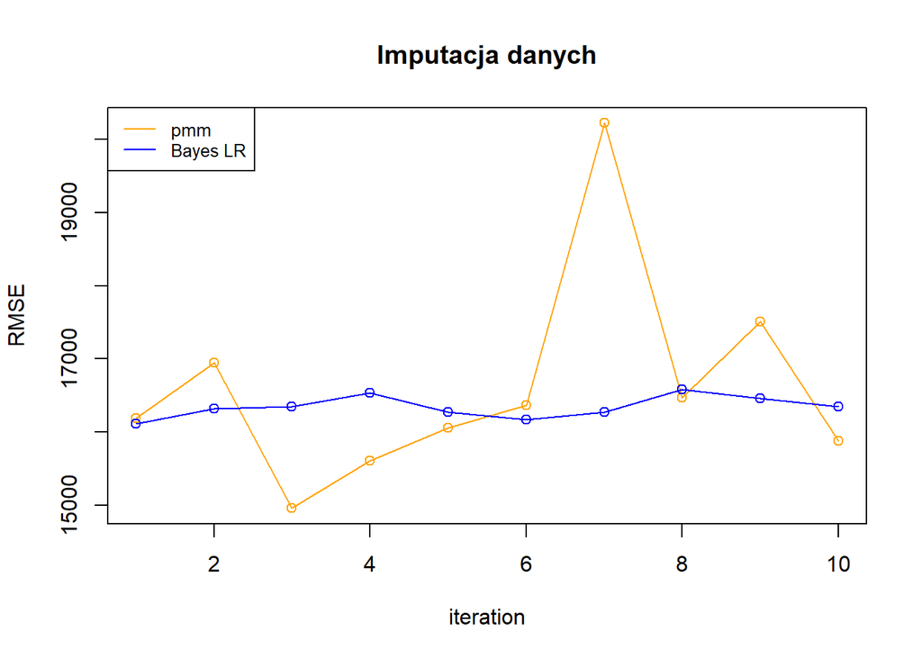

```r
plot(error_pmm,col = "orange",
     main = "Imputacja danych",
     xlab = "iteration", ylab = "RMSE")
lines(error_pmm,col = "orange")

points(error_norm,col = "blue", add = TRUE)
lines(error_norm,col = "blue", add = TRUE)

legend("topleft", legend=c("pmm", "Bayes LR"),
       col=c("orange", "blue"), lty=1, cex=0.8)
```

Algorytm Bayes Linear Regression okazał się być lepszy; mniejsze pole pod wykresem błędu RMSE. Działa również szybciej od Predictive Mean Matching (pmm) i można go łatwiej tuningować. Zastosowałem go z takimi samymi prametrami co pmm.

PMM ma kilka razy wieksze odchylenie standardowe:

```r
sd(error_pmm)
```

```
## [1] 1444.558
```

```r
sd(error_norm)
```

```
## [1] 148.6915
```

## 2.3 10% losowych it_quantity jako NA

```r
aux_na <- aux %>% mutate(
  it_quantity =
    unlist(
      prodNA(aux %>% select(it_quantity), noNA = 0.1)
    )
)
head(aux_na,15)
```

|  | it_quantity | price | it_seller_rating |
| --- | --- | --- | --- |
| 1 | 3 | 299.0 | 8221 |
| 2 | 976 | 130.0 | 31 |
| 3 | 400 | 13.9 | 9812 |
| 4 | 0 | 32.0 | 5010 |
| 5 | 420 | 49.9 | 69816 |
| 6 | 92 | 39.9 | 71774 |
| 7 | 172 | 1049.0 | 6219 |
| 8 | 11 | 335.0 | 3645 |
| 9 | 38 | 41.0 | 10063 |
| 10 | 9617 | 24.9 | 28925 |

[output cut: 5 more lines]

Imputacja pmm & Bayesian linear regression:

```r
error_pmm <- numeric(0)
error_norm <- numeric(0)

for (i in 1:10){

  # ->  "pmm"
  data_imputed <- mice(aux_na, m = 1, method = "pmm", maxit = 1) # 1 iteration(maxit)

  data_imputed_2 <- complete(data_imputed, 1) # obtain 1st imputation
  blad <- sqrt(mean((aux$it_quantity - data_imputed_2$it_quantity)^2)) # RMSD
  error_pmm <- c(error_pmm, blad)

  # ->  "norm" Bayesian linear regression
  data_imputed <- mice(aux_na, m = 1, method = "norm", maxit = 1) # 1 iteration(maxit)

  data_imputed_2 <- complete(data_imputed, 1) # obtain 1st imputation
  blad <- sqrt(mean((aux$it_quantity - data_imputed_2$it_quantity)^2)) # RMSD
  error_norm <- c(error_norm, blad)

}
```

Wyniki przedstawiam na wykresie:

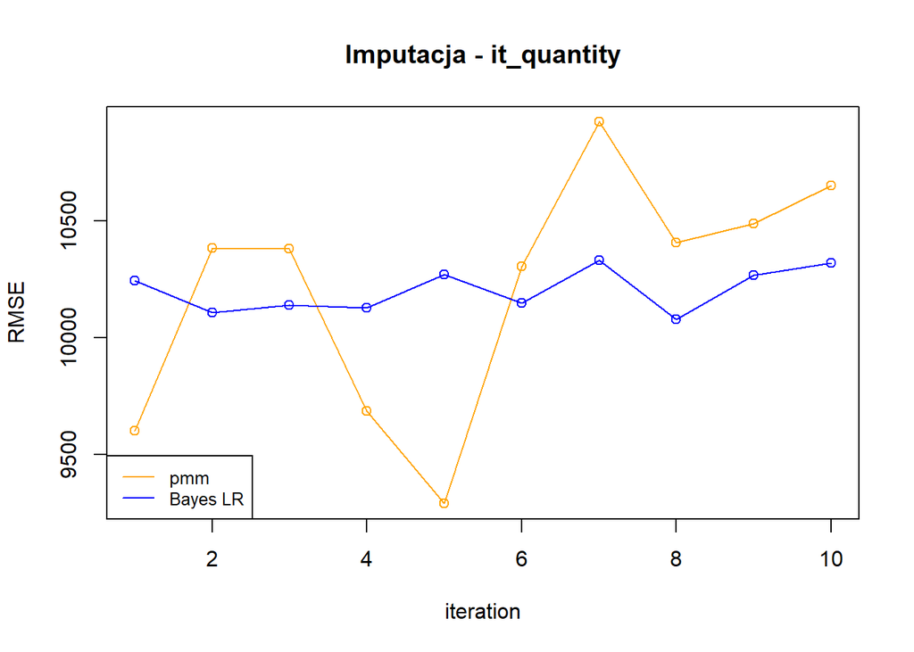

```r
plot(error_pmm,col = "orange",
     main = "Imputacja - it_quantity",
     xlab = "iteration", ylab = "RMSE")
lines(error_pmm,col = "orange")

points(error_norm,col = "blue", add = TRUE)
lines(error_norm,col = "blue", add = TRUE)

legend("bottomleft", legend=c("pmm", "Bayes LR"),
       col=c("orange", "blue"), lty=1, cex=0.8)
```

Tutaj ciężko stwierdzić który algorytm okazał się być lepszy. Bayes LR miał zazwyczaj mniejszą wartość błędu.

Natomiast PMM ma ponownie kilka razy większe odchylenie standardowe:

```r
sd(error_pmm)
```

```
## [1] 513.9337
```

```r
sd(error_norm)
```

```
## [1] 92.74902
```

# 3 Wnioski

W pracy przedstawiono różne sposoby kodowania zmiennych kategorycznych. Bardzo ważne jest aby nie traktować tym algorytmem zmiennej typu jakościowego, mającej zbyt dużą liczbę klas. W przeciwnym razie może prowadzić to do overfittingu lub olbrzymim wzrostem wymiaru danych. Innym dobrym sposobem było usunięcie rzadko występujących klas i nadanie im wspólnej kategorii ‘Others’. Ten sposób gwarantuje nam stałą (albo kontrolowaną) liczbę kolumn po procesie kodowania.

Są również inne metody kodowania, nie zaprezentowane w tym projekcie. Przykładem może być **Cross-fold encoding**, który dzieli zbiór danych na k cześci (k > 1) i dla każdej kategorii A z danej części przyporządkowywuje średnią kolumny celu z innej części niż k-ta. Otrzymujmy w wyniku k razy więcej etykietek.

A propos imputacji danych, algorytm Bayes LR obarczony był błędem o mniejszym odchyleniu standardowym. W użyciu był również szybszy od PMM. Niemniej jednak, mimo jego szybkości zdecydowałem się na redukcję danych do losowych 10% wierszy wejściowej ramki danych.

Pakiet mice, z którego pochodzą powyższe algorytmy, posiada wiele innych metod godnych przetestowania. Wiele z nich dotyczą zmiennych typu binarnego, jakościowego, uporządkowanego albo nieuporządkowanego. Używana w tym projekcie metoda PMM jest algorytmem dla danych dowolnych, a Bayes LR dla danych numerycznych.

Z uwagi na dużą liczbę wierszy - około 40000, błąd RMSE z zakresu 10000 i 16000 dla danych **it_quantity oraz it_seller_rating** z szerokich zakresów, odpowiednio **(0 , 99 999) oraz (-1 , 292 074)**, jest relatywnie niski. Zatem otrzymana imputacja jest akceptowalna.